# Recent falls

# 1 Description of DataSchema variable

The description of harmonised variable is the following:

- Short name: `recent_falls`
- Variable label: `Recent falls in the last 6-24 months`
- Variable description: `Recent falls in the last 6-24 months`
- Domain: `Health status and functional limitations`
- Value type: `categorical`
- Category coding:

| **Code** | **Category Label** |
| --- | --- |
| 0 | No |
| 1 | Yes |

- Category missings:

| **Code** | **Category Label** |
| --- | --- |
| 991 | CAPI/interviewer error |
| 992 | Impute |
| 993 | Disable to measure |
| 994 | Not attempt/not done |
| 995 | Does not answer |
| 996 | Not applicable |
| 997 | Refuse |
| 998 | Do not know |
| 999 | Missing |

# 2 Data process

## 2.1 ELSA

### 2.1.1 Wave 1

#### 2.1.1.1 Study-specific variable description

The study-specific variables elected to be harmonised is:

- Name: `hefla`
- Label: `Have you fallen down in the last two years (for any reason)?`
- Categories:
- `1 = Yes`
- `2 = No`
- Missings
- `-9 = Refusal`
- `-8 = Don't know`
- `-1 = Not applicable`

Recent falls

| Sample size | Missing values |
| --- | --- |
| 12099 | 200 |

Category

|  | -1 | 1 | 2 |
| --- | --- | --- | --- |
| Frequency | 4980.00 | 2188.00 | 4731.0 |
| Percentage | 41.16 | 18.08 | 39.1 |

Type of missing

|  | -9 | -8 | NA |
| --- | --- | --- | --- |
| Frequency | 189.00 | 11.00 | 0 |
| Percentage | 1.56 | 0.09 | 0 |

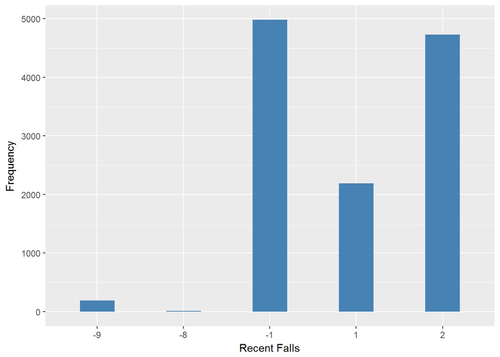

#### 2.1.1.2 Harmonisation algorithm

To compute the harmonize variable from the study-specific variable it has to be recoded as follows:

- `2 into 0`
- `-9 Refusal into 997`
- `-8 Don't know into 998`
- `-1 Not applicable into 996`

**R script:**

```r
ELSA_ds_w1 <- tibble(id=ELSA_w1_recent_falls$id)
ELSA_ds_w1$recent_falls <- recode(ELSA_w1_recent_falls$hefla, "2 = '0';-9 = '997';-8 = '998';-1 = '996' ")
ELSA_ds_w1$recent_falls <- labelled(ELSA_ds_w1$recent_falls, labels = c("Yes"=0, "No"=1,"Missing"=999, "Do not know"=998, "Refuse"=997, "Not applicable"=996, "Does not answer"=995,  "Not attempt not done"=994, "Disable to measure"=993, "Impute"=992, "CAPI interviewer error"=991))
```

#### 2.1.1.3 Statistical description of the new harmonised variable

Recent falls

| Sample size | Missing values |
| --- | --- |
| 12099 | 5180 |

Category

|  | 0 | 1 |
| --- | --- | --- |
| Frequency | 4731.0 | 2188.00 |
| Percentage | 39.1 | 18.08 |

Type of missing

|  | 991 | 992 | 993 | 994 | 995 | 996 | 997 | 998 | 999 | NA |
| --- | --- | --- | --- | --- | --- | --- | --- | --- | --- | --- |
| Frequency | 0 | 0 | 0 | 0 | 0 | 4980.00 | 189.00 | 11.00 | 0 | 0 |
| Percentage | 0 | 0 | 0 | 0 | 0 | 41.16 | 1.56 | 0.09 | 0 | 0 |

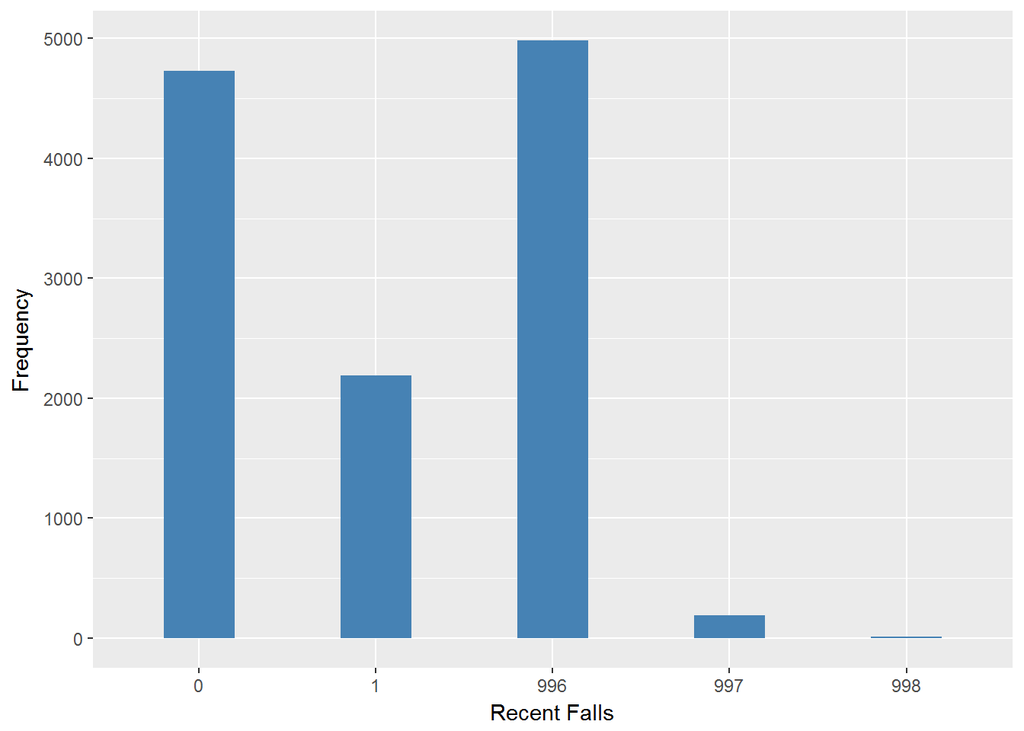

#### 2.1.1.4 Validation

|  | 2->0 | 1 | -1->996 | -9->997 | -8->998 |
| --- | --- | --- | --- | --- | --- |
| BeforeH | 4731 | 2188 | 4980 | 189 | 11 |
| AfterH | 4731 | 2188 | 4980 | 189 | 11 |

### 2.1.2 Wave 2

#### 2.1.2.1 Study-specific variable description

The study-specific variables elected to be harmonised is:

Recent falls

| Sample size | Missing values |
| --- | --- |
| 9432 | 3289 |

Category

|  | 1 | 2 |
| --- | --- | --- |
| Frequency | 2022.00 | 4121.00 |
| Percentage | 21.44 | 43.69 |

Type of missing

|  | -1 | -9 | -8 | NA |
| --- | --- | --- | --- | --- |
| Frequency | 3283.00 | 3.00 | 3.00 | 0 |
| Percentage | 34.81 | 0.03 | 0.03 | 0 |

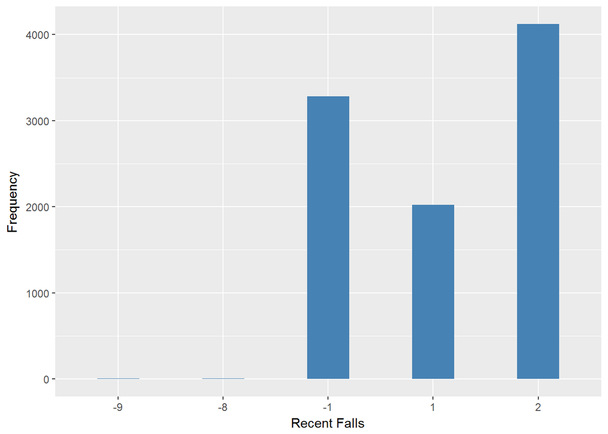

#### 2.1.2.2 Harmonisation algorithm

To compute the harmonize variable from the study-specific variable it has to be recoded as follows:

- `2 into 0`
- `-9 Refusal into 997`
- `-8 Don't know into 998`
- `-1 Not applicable into 996`

**R script:**

```r
ELSA_ds_w2 <- tibble(id=ELSA_w2_recent_falls$id)
ELSA_ds_w2$recent_falls <- recode(ELSA_w2_recent_falls$HeFla, "2 = '0';-9 = '997';-8 = '998';-1 = '996' ")
ELSA_ds_w2$recent_falls <- labelled(ELSA_ds_w2$recent_falls, labels = c("Yes"=0, "No"=1,"Missing"=999, "Do not know"=998, "Refuse"=997, "Not applicable"=996, "Does not answer"=995,  "Not attempt not done"=994, "Disable to measure"=993, "Impute"=992, "CAPI interviewer error"=991))
```

#### 2.1.2.3 Statistical description of the new harmonised variable

Recent falls

| Sample size | Missing values |
| --- | --- |
| 9432 | 3289 |

Category

|  | 0 | 1 |
| --- | --- | --- |
| Frequency | 4121.00 | 2022.00 |
| Percentage | 43.69 | 21.44 |

Type of missing

|  | 991 | 992 | 993 | 994 | 995 | 996 | 997 | 998 | 999 | NA |
| --- | --- | --- | --- | --- | --- | --- | --- | --- | --- | --- |
| Frequency | 0 | 0 | 0 | 0 | 0 | 3283.00 | 3.00 | 3.00 | 0 | 0 |
| Percentage | 0 | 0 | 0 | 0 | 0 | 34.81 | 0.03 | 0.03 | 0 | 0 |

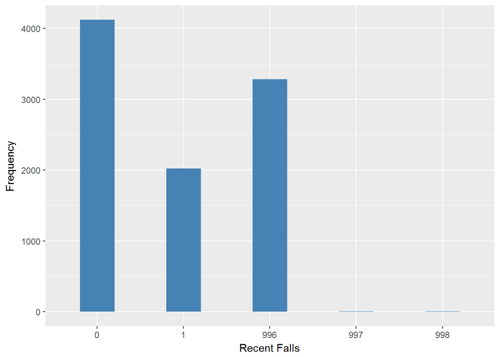

#### 2.1.2.4 Validation

|  | 2->0 | 1 | -1->996 | -9->997 | -8->998 |
| --- | --- | --- | --- | --- | --- |
| BeforeH | 4121 | 2022 | 3283 | 3 | 3 |
| AfterH | 4121 | 2022 | 3283 | 3 | 3 |

### 2.1.3 Wave 3

#### 2.1.3.1 Study-specific variable description

The study-specific variables elected to be harmonised is:

- Name: `hefla`
- Label: `Whether fallen down`
- Categories:
- `1 = Yes`
- `2 = No`
- Missings
- `-8 = Don't know`
- `-1 = Not applicable`

Recent falls

| Sample size | Missing values |
| --- | --- |
| 9771 | 4041 |

Category

|  | 1 | 2 |
| --- | --- | --- |
| Frequency | 1758.00 | 3972.00 |
| Percentage | 17.99 | 40.65 |

Type of missing

|  | -1 | -8 | NA |
| --- | --- | --- | --- |
| Frequency | 4036.00 | 5.00 | 0 |
| Percentage | 41.31 | 0.05 | 0 |

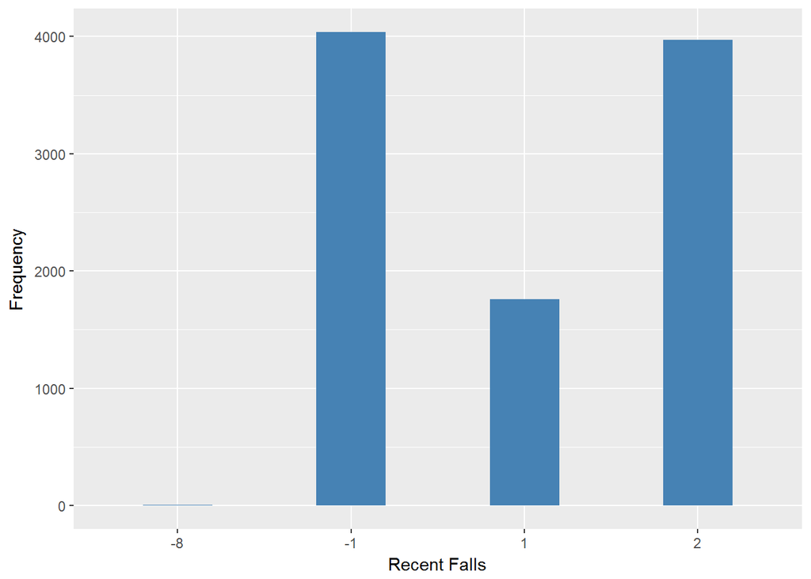

#### 2.1.3.2 Harmonisation algorithm

To compute the harmonize variable from the study-specific variable it has to be recoded as follows:

- `2 into 0`
- `-8 Don't know into 998`
- `-1 Not applicable into 996`

**R script:**

```r
ELSA_ds_w3 <- tibble(id=ELSA_w3_recent_falls$id)
ELSA_ds_w3$recent_falls <- recode(ELSA_w3_recent_falls$hefla, "2 = '0';-9 = '997';-8 = '998';-1 = '996' ")
ELSA_ds_w3$recent_falls <- labelled(ELSA_ds_w3$recent_falls, labels = c("Yes"=0, "No"=1,"Missing"=999, "Do not know"=998, "Refuse"=997, "Not applicable"=996, "Does not answer"=995,  "Not attempt not done"=994, "Disable to measure"=993, "Impute"=992, "CAPI interviewer error"=991))
```

#### 2.1.3.3 Statistical description of the new harmonised variable

Recent falls

| Sample size | Missing values |
| --- | --- |
| 9771 | 4041 |

Category

|  | 0 | 1 |
| --- | --- | --- |
| Frequency | 3972.00 | 1758.00 |
| Percentage | 40.65 | 17.99 |

Type of missing

|  | 991 | 992 | 993 | 994 | 995 | 996 | 997 | 998 | 999 | NA |
| --- | --- | --- | --- | --- | --- | --- | --- | --- | --- | --- |
| Frequency | 0 | 0 | 0 | 0 | 0 | 4036.00 | 0 | 5.00 | 0 | 0 |
| Percentage | 0 | 0 | 0 | 0 | 0 | 41.31 | 0 | 0.05 | 0 | 0 |

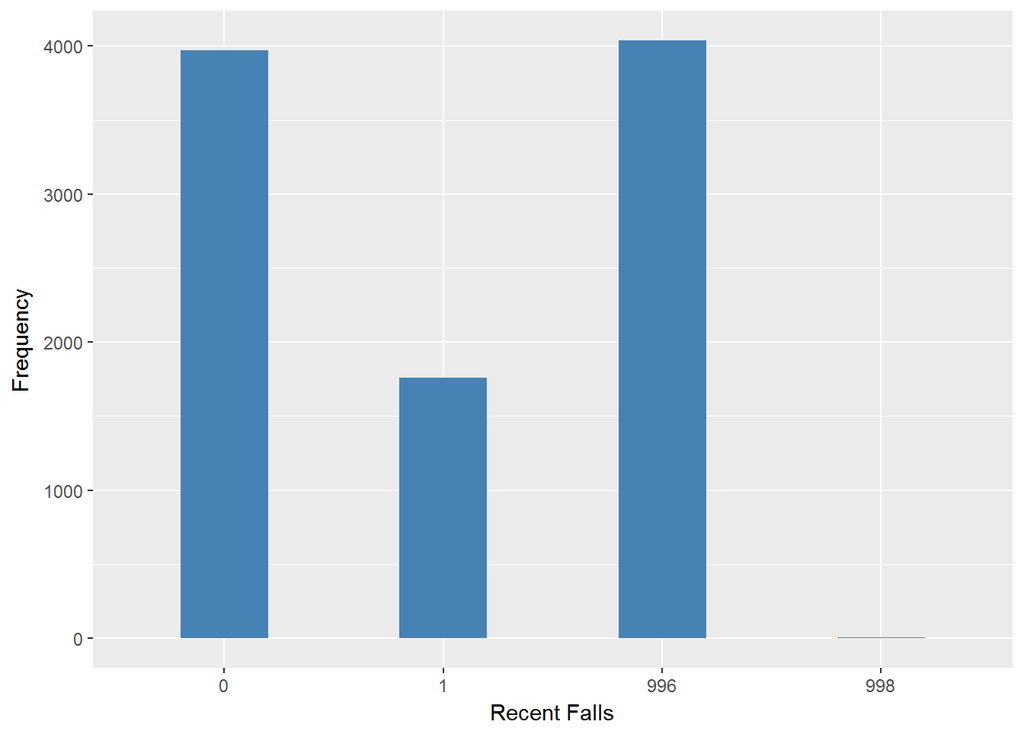

#### 2.1.3.4 Validation

|  | 2->0 | 1 | -1->996 | -8->998 |
| --- | --- | --- | --- | --- |
| BeforeH | 3972 | 1758 | 4036 | 5 |
| AfterH | 3972 | 1758 | 4036 | 5 |

### 2.1.4 Wave 4

#### 2.1.4.1 Study-specific variable description

The study-specific variables elected to be harmonised is:

- Name: `hefla`
- Label: `Whether fallen down in the last year`
- Categories:
- `1 = Yes`
- `2 = No`
- Missings
- `-8 = Don't know`
- `-1 = Not applicable`

Recent falls

| Sample size | Missing values |
| --- | --- |
| 11050 | 4036 |

Category

|  | 1 | 2 |
| --- | --- | --- |
| Frequency | 1849.00 | 5165.00 |
| Percentage | 16.73 | 46.74 |

Type of missing

|  | -1 | -8 | NA |
| --- | --- | --- | --- |
| Frequency | 4030.00 | 6.00 | 0 |
| Percentage | 36.47 | 0.05 | 0 |

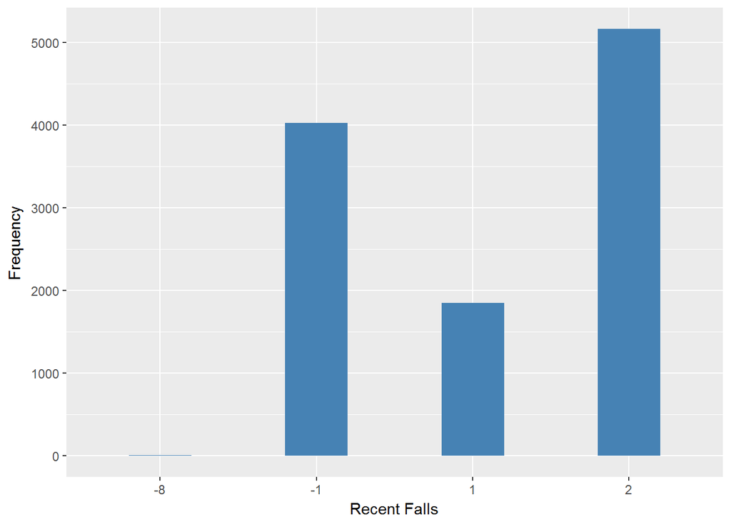

#### 2.1.4.2 Harmonisation algorithm

To compute the harmonize variable from the study-specific variable it has to be recoded as follows:

- `2 into 0`
- `-8 Don't know into 998`
- `-1 Not applicable into 996`

**R script:**

```r
ELSA_ds_w4 <- tibble(id=ELSA_w4_recent_falls$id)
ELSA_ds_w4$recent_falls <- recode(ELSA_w4_recent_falls$hefla, ";2 = '0';-9 = '997';-8 = '998';-1 = '996' ")
ELSA_ds_w4$recent_falls <- labelled(ELSA_ds_w4$recent_falls, labels = c("Yes"=0, "No"=1,"Missing"=999, "Do not know"=998, "Refuse"=997, "Not applicable"=996, "Does not answer"=995,  "Not attempt not done"=994, "Disable to measure"=993, "Impute"=992, "CAPI interviewer error"=991))
```

#### 2.1.4.3 Statistical description of the new harmonised variable

Recent falls

| Sample size | Missing values |
| --- | --- |
| 11050 | 4036 |

Category

|  | 0 | 1 |
| --- | --- | --- |
| Frequency | 5165.00 | 1849.00 |
| Percentage | 46.74 | 16.73 |

Type of missing

|  | 991 | 992 | 993 | 994 | 995 | 996 | 997 | 998 | 999 | NA |
| --- | --- | --- | --- | --- | --- | --- | --- | --- | --- | --- |
| Frequency | 0 | 0 | 0 | 0 | 0 | 4030.00 | 0 | 6.00 | 0 | 0 |
| Percentage | 0 | 0 | 0 | 0 | 0 | 36.47 | 0 | 0.05 | 0 | 0 |

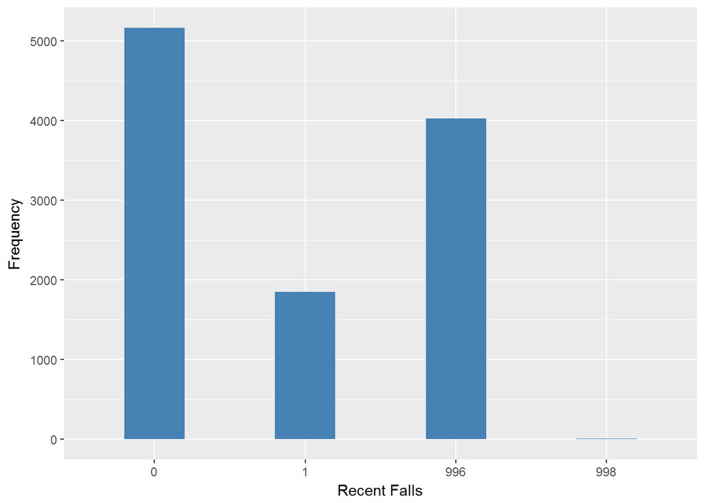

#### 2.1.4.4 Validation

|  | 2->0 | 1 | -1->996 | -8->998 |
| --- | --- | --- | --- | --- |
| BeforeH | 5165 | 1849 | 4030 | 6 |
| AfterH | 5165 | 1849 | 4030 | 6 |

### 2.1.5 Wave 5

#### 2.1.5.1 Study-specific variable description

The study-specific variables elected to be harmonised is:

- Name: `hefla`
- Label: `Whether fallen down`
- Categories:
- `1 = Yes`
- `2 = No`
- Missings
- `-9 = Refusal`
- `-8 = Don't know`
- `-2 = Capi/Interviewer Error`
- `-1 = Not applicable`

Recent falls

| Sample size | Missing values |
| --- | --- |
| 10274 | 3131 |

Category

|  | 1 | 2 |
| --- | --- | --- |
| Frequency | 2042.00 | 5101.00 |
| Percentage | 19.88 | 49.65 |

Type of missing

|  | -9 | -8 | -2 | -1 | NA |
| --- | --- | --- | --- | --- | --- |
| Frequency | 2.00 | 5.00 | 1.00 | 3123.0 | 0 |
| Percentage | 0.02 | 0.05 | 0.01 | 30.4 | 0 |

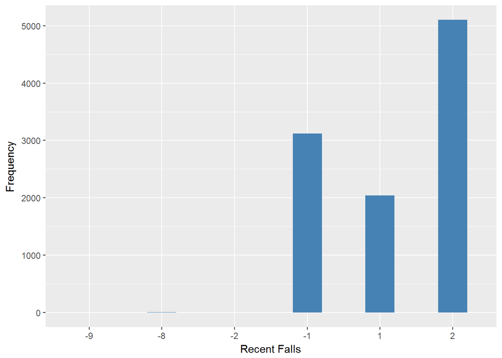

#### 2.1.5.2 Harmonisation algorithm

To compute the harmonize variable from the study-specific variable it has to be recoded as follows:

- `2 into 0`
- `-9 Refusal into 997`
- `-8 Don't know into 998`
- `-2 Capi/Interviewer Error into 991`
- `-1 Not applicable into 996`

**R script:**

```r
ELSA_ds_w5 <- tibble(id=ELSA_w5_recent_falls$id)
ELSA_ds_w5$recent_falls <- recode(ELSA_w5_recent_falls$hefla, "2 = '0';-9 = '997';-8 = '998';-2 = '991';-1 = '996' ")
ELSA_ds_w5$recent_falls <- labelled(ELSA_ds_w5$recent_falls, labels = c("Yes"=0, "No"=1,"Missing"=999, "Do not know"=998, "Refuse"=997, "Not applicable"=996, "Does not answer"=995,  "Not attempt not done"=994, "Disable to measure"=993, "Impute"=992, "CAPI interviewer error"=991))
```

#### 2.1.5.3 Statistical description of the new harmonised variable

Recent falls

| Sample size | Missing values |
| --- | --- |
| 10274 | 3131 |

Category

|  | 0 | 1 |
| --- | --- | --- |
| Frequency | 5101.00 | 2042.00 |
| Percentage | 49.65 | 19.88 |

Type of missing

|  | 991 | 992 | 993 | 994 | 995 | 996 | 997 | 998 | 999 | NA |
| --- | --- | --- | --- | --- | --- | --- | --- | --- | --- | --- |
| Frequency | 1.00 | 0 | 0 | 0 | 0 | 3123.0 | 2.00 | 5.00 | 0 | 0 |
| Percentage | 0.01 | 0 | 0 | 0 | 0 | 30.4 | 0.02 | 0.05 | 0 | 0 |

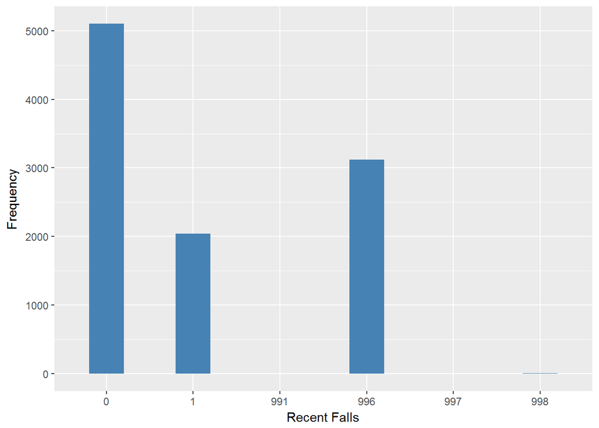

#### 2.1.5.4 Validation

|  | 2->0 | 1 | -2->991 | -1->996 | -9->997 | -8->998 |
| --- | --- | --- | --- | --- | --- | --- |
| BeforeH | 5101 | 2042 | 1 | 3123 | 2 | 5 |
| AfterH | 5101 | 2042 | 1 | 3123 | 2 | 5 |

#### 2.1.6.1 Study-specific variable description

The study-specific variables elected to be harmonised is:

- Name: `HeFla`
- Label: `Whether fallen down`
- Categories:
- `1 = Yes`
- `2 = No`
- Missings
- `-9 = Refusal`
- `-8 = Don't know`
- `-1 = Not applicable`

Recent falls

| Sample size | Missing values |
| --- | --- |
| 10601 | 3365 |

Category

|  | 1 | 2 |
| --- | --- | --- |
| Frequency | 2038.00 | 5198.00 |
| Percentage | 19.22 | 49.03 |

Type of missing

|  | -9 | -8 | -1 | NA |
| --- | --- | --- | --- | --- |
| Frequency | 4.00 | 3.00 | 3358.00 | 0 |
| Percentage | 0.04 | 0.03 | 31.68 | 0 |

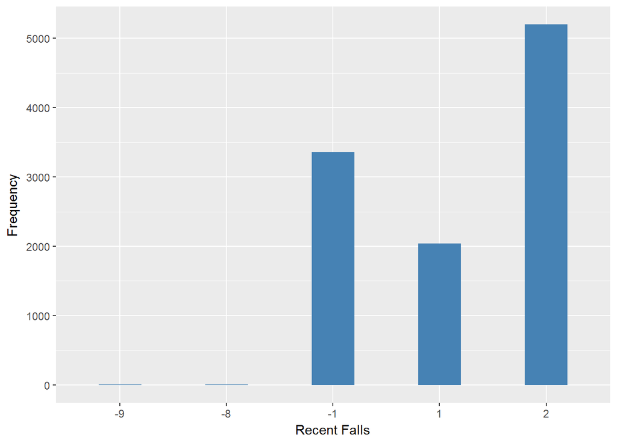

#### 2.1.6.2 Harmonisation algorithm

To compute the harmonize variable from the study-specific variable it has to be recoded as follows:

- `2 into 0`
- `-9 Refusal into 997`
- `-8 Don't know into 998`
- `-1 Not applicable into 996`

**R script:**

```r
ELSA_ds_w6 <- tibble(id=ELSA_w6_recent_falls$id)
ELSA_ds_w6$recent_falls <- recode(ELSA_w6_recent_falls$HeFla, ";2 = '0';-9 = '997';-8 = '998';-1 = '996' ")
ELSA_ds_w6$recent_falls <- labelled(ELSA_ds_w6$recent_falls, labels = c("Yes"=0, "No"=1,"Missing"=999, "Do not know"=998, "Refuse"=997, "Not applicable"=996, "Does not answer"=995,  "Not attempt not done"=994, "Disable to measure"=993, "Impute"=992, "CAPI interviewer error"=991))
```

#### 2.1.6.3 Statistical description of the new harmonised variable

Recent falls

| Sample size | Missing values |
| --- | --- |
| 10601 | 3365 |

Category

|  | 0 | 1 |
| --- | --- | --- |
| Frequency | 5198.00 | 2038.00 |
| Percentage | 49.03 | 19.22 |

Type of missing

|  | 991 | 992 | 993 | 994 | 995 | 996 | 997 | 998 | 999 | NA |
| --- | --- | --- | --- | --- | --- | --- | --- | --- | --- | --- |
| Frequency | 0 | 0 | 0 | 0 | 0 | 3358.00 | 4.00 | 3.00 | 0 | 0 |
| Percentage | 0 | 0 | 0 | 0 | 0 | 31.68 | 0.04 | 0.03 | 0 | 0 |

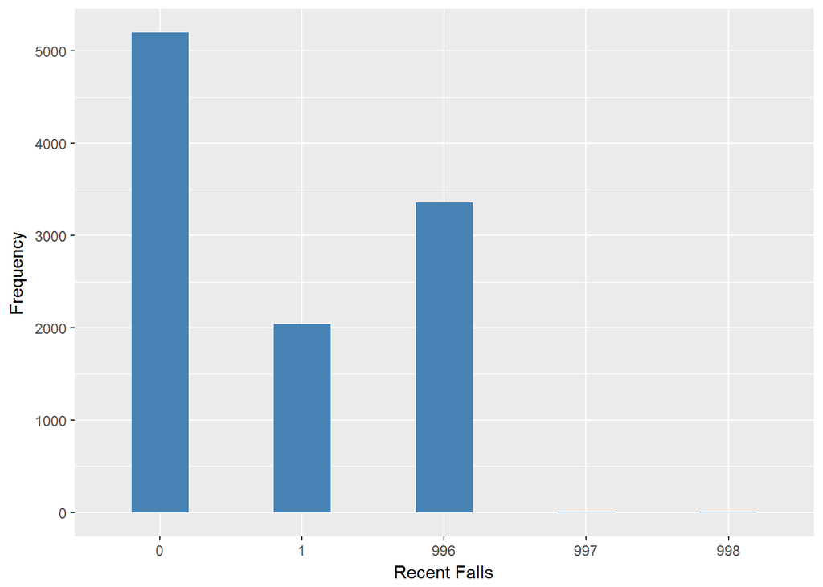

#### 2.1.6.4 Validation

|  | 2->0 | 1 | -1->996 | -9->997 | -8->998 |
| --- | --- | --- | --- | --- | --- |
| BeforeH | 5198 | 2038 | 3358 | 4 | 3 |
| AfterH | 5198 | 2038 | 3358 | 4 | 3 |

### 2.1.7 Wave 7

#### 2.1.7.1 Study-specific variable description

The study-specific variables elected to be harmonised is:

- Name: `HeFla`
- Label: `Whether fallen down`
- Categories:
- `1 = Yes`
- `2 = No`
- Missings
- `-9 = Refusal`
- `-8 = Don't know`
- `-1 = Not applicable`

Recent falls

| Sample size | Missing values |
| --- | --- |
| 9666 | 2708 |

Category

|  | 1 | 2 |
| --- | --- | --- |
| Frequency | 1863.00 | 5095.00 |
| Percentage | 19.27 | 52.71 |

Type of missing

|  | -9 | -8 | -1 | NA |
| --- | --- | --- | --- | --- |
| Frequency | 6.00 | 1.00 | 2701.00 | 0 |
| Percentage | 0.06 | 0.01 | 27.94 | 0 |

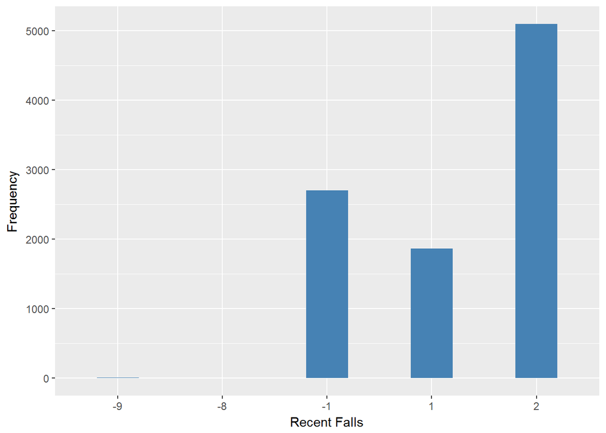

#### 2.1.7.2 Harmonisation algorithm

To compute the harmonize variable from the study-specific variable it has to be recoded as follows:

- `2 into 0`
- `-9 Refusal into 997`
- `-8 Don't know into 998`
- `-1 Not applicable into 996`

**R script:**

```r
ELSA_ds_w7 <- tibble(id=ELSA_w7_recent_falls$id)
ELSA_ds_w7$recent_falls <- recode(ELSA_w7_recent_falls$HeFla, "2 = '0';-9 = '997';-8 = '998';-1 = '996' ")
ELSA_ds_w7$recent_falls <- labelled(ELSA_ds_w7$recent_falls, labels = c("Yes"=0, "No"=1,"Missing"=999, "Do not know"=998, "Refuse"=997, "Not applicable"=996, "Does not answer"=995,  "Not attempt not done"=994, "Disable to measure"=993, "Impute"=992, "CAPI interviewer error"=991))
```

#### 2.1.7.3 Statistical description of the new harmonised variable

Recent falls

| Sample size | Missing values |
| --- | --- |
| 9666 | 2708 |

Category

|  | 0 | 1 |
| --- | --- | --- |
| Frequency | 5095.00 | 1863.00 |
| Percentage | 52.71 | 19.27 |

Type of missing

|  | 991 | 992 | 993 | 994 | 995 | 996 | 997 | 998 | 999 | NA |
| --- | --- | --- | --- | --- | --- | --- | --- | --- | --- | --- |
| Frequency | 0 | 0 | 0 | 0 | 0 | 2701.00 | 6.00 | 1.00 | 0 | 0 |
| Percentage | 0 | 0 | 0 | 0 | 0 | 27.94 | 0.06 | 0.01 | 0 | 0 |

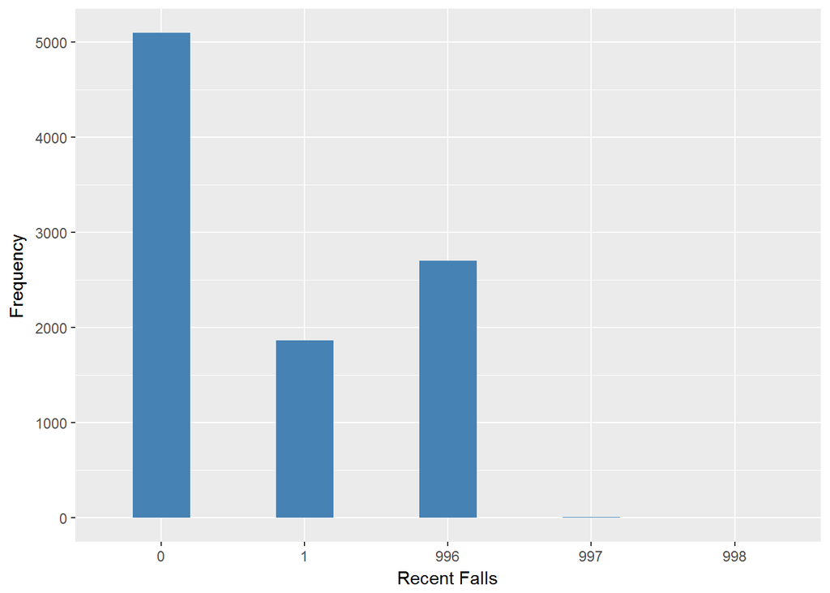

#### 2.1.7.4 Validation

|  | 2->0 | 1 | -1->996 | -9->997 | -8->998 |
| --- | --- | --- | --- | --- | --- |
| BeforeH | 5095 | 1863 | 2701 | 6 | 1 |
| AfterH | 5095 | 1863 | 2701 | 6 | 1 |

# 3 Quality estimation

### 3.0.1 Summary of descriptive statistics of the harmonised variable accross populations and waves

Two tables are generated:

1. Percentages of categories in each harmonised variable.
2. Frequencies and percentages of individuals with different trajectories. To avoid too large table, Only trajectories with percentages larger than 0.3 are shown.

```r
ELSA_ds_w1$recent_falls <- labelled(ELSA_ds_w1$recent_falls, labels = c(No=0, Yes=1, Missing=999, Do_not_know=998, Refuse=997, Not_applicable=996, Does_not_answer=995,  Not_attempt_not_done=994, Disable_to_measure=993, Impute=992, CAPI_interviewer_error=991))
ELSA_ds_w2$recent_falls <- labelled(ELSA_ds_w2$recent_falls, labels = c(No=0, Yes=1, Missing=999, Do_not_know=998, Refuse=997, Not_applicable=996, Does_not_answer=995,  Not_attempt_not_done=994, Disable_to_measure=993, Impute=992, CAPI_interviewer_error=991))
ELSA_ds_w3$recent_falls <- labelled(ELSA_ds_w3$recent_falls, labels = c(No=0, Yes=1, Missing=999, Do_not_know=998, Refuse=997, Not_applicable=996, Does_not_answer=995,  Not_attempt_not_done=994, Disable_to_measure=993, Impute=992, CAPI_interviewer_error=991))
ELSA_ds_w4$recent_falls <- labelled(ELSA_ds_w4$recent_falls, labels = c(No=0, Yes=1, Missing=999, Do_not_know=998, Refuse=997, Not_applicable=996, Does_not_answer=995,  Not_attempt_not_done=994, Disable_to_measure=993, Impute=992, CAPI_interviewer_error=991))
ELSA_ds_w5$recent_falls <- labelled(ELSA_ds_w5$recent_falls, labels = c(No=0, Yes=1, Missing=999, Do_not_know=998, Refuse=997, Not_applicable=996, Does_not_answer=995,  Not_attempt_not_done=994, Disable_to_measure=993, Impute=992, CAPI_interviewer_error=991))
ELSA_ds_w6$recent_falls <- labelled(ELSA_ds_w6$recent_falls, labels = c(No=0, Yes=1, Missing=999, Do_not_know=998, Refuse=997, Not_applicable=996, Does_not_answer=995,  Not_attempt_not_done=994, Disable_to_measure=993, Impute=992, CAPI_interviewer_error=991))
ELSA_ds_w7$recent_falls <- labelled(ELSA_ds_w7$recent_falls, labels = c(No=0, Yes=1, Missing=999, Do_not_know=998, Refuse=997, Not_applicable=996, Does_not_answer=995,  Not_attempt_not_done=994, Disable_to_measure=993, Impute=992, CAPI_interviewer_error=991))

tt <-    frq(ELSA_ds_w1$recent_falls)[[1]][,c(1:2,4)]
tt[4] <- frq(ELSA_ds_w2$recent_falls)[[1]][,c(4)]
tt[5] <- frq(ELSA_ds_w3$recent_falls)[[1]][,c(4)]
tt[6] <- frq(ELSA_ds_w4$recent_falls)[[1]][,c(4)]
tt[7] <- frq(ELSA_ds_w5$recent_falls)[[1]][,c(4)]
tt[8] <- frq(ELSA_ds_w6$recent_falls)[[1]][,c(4)]
tt[9] <- frq(ELSA_ds_w7$recent_falls)[[1]][,c(4)]
tt[13,] <- c("n", "sample size",
             length(ELSA_ds_w1$recent_falls), length(ELSA_ds_w2$recent_falls), length(ELSA_ds_w3$recent_falls),
             length(ELSA_ds_w4$recent_falls), length(ELSA_ds_w5$recent_falls), length(ELSA_ds_w6$recent_falls),
             length(ELSA_ds_w7$recent_falls))
names(tt)<-c("val", "label", "w1", "w2", "w3", "w4", "w5", "w6", "w7")
kable(tt)
```

| val | label | w1 | w2 | w3 | w4 | w5 | w6 | w7 |
| --- | --- | --- | --- | --- | --- | --- | --- | --- |
| 0 | No | 39.1 | 43.69 | 40.65 | 46.74 | 49.65 | 49.03 | 52.71 |
| 1 | Yes | 18.08 | 21.44 | 17.99 | 16.73 | 19.88 | 19.22 | 19.27 |
| 991 | CAPI_interviewer_error | 0 | 0 | 0 | 0 | 0.01 | 0 | 0 |
| 992 | Impute | 0 | 0 | 0 | 0 | 0 | 0 | 0 |
| 993 | Disable_to_measure | 0 | 0 | 0 | 0 | 0 | 0 | 0 |
| 994 | Not_attempt_not_done | 0 | 0 | 0 | 0 | 0 | 0 | 0 |
| 995 | Does_not_answer | 0 | 0 | 0 | 0 | 0 | 0 | 0 |
| 996 | Not_applicable | 41.16 | 34.81 | 41.31 | 36.47 | 30.4 | 31.68 | 27.94 |
| 997 | Refuse | 1.56 | 0.03 | 0 | 0 | 0.02 | 0.04 | 0.06 |
| 998 | Do_not_know | 0.09 | 0.03 | 0.05 | 0.05 | 0.05 | 0.03 | 0.01 |
| 999 | Missing | 0 | 0 | 0 | 0 | 0 | 0 | 0 |
| NA | NA | 0 | 0 | 0 | 0 | 0 | 0 | 0 |
| n | sample size | 12099 | 9432 | 9771 | 11050 | 10274 | 10601 | 9666 |

```r
dbb <- merge(ELSA_m_ds_w1, ELSA_m_ds_w2, by="id", suffixes = c(".w1",".w2"), all=T)
dbb <- merge(dbb, ELSA_m_ds_w3, by="id", all=T)
dbb <- merge(dbb, ELSA_m_ds_w4, by="id", suffixes = c(".w3",".w4"), all=T)
dbb <- merge(dbb, ELSA_m_ds_w5, by="id", all=T)
dbb <- merge(dbb, ELSA_m_ds_w6, by="id", suffixes = c(".w5",".w6"), all=T)
dbb <- merge(dbb, ELSA_m_ds_w7, by="id", all=T)
names(dbb) <- c("id", "w1", "w2", "w3", "w4", "w5", "w6", "w7")
v.dbb <- paste(dbb[,2],dbb[,3],dbb[,4],dbb[,5],dbb[,6],dbb[,7],dbb[,8],sep="")
f.dbb <- frq(v.dbb)[[1]][,c(1,2,4)]
kable(f.dbb[f.dbb[,3]>=0.3,])
```

|  | val | frq | raw.prc |
| --- | --- | --- | --- |
| 1 | 0000000 | 425 | 2.30 |
| 2 | 0000001 | 86 | 0.47 |
| 3 | 000000NA | 86 | 0.47 |
| 4 | 0000010 | 73 | 0.39 |
| 9 | 00000NANA | 92 | 0.50 |
| 25 | 0000NANANA | 127 | 0.69 |
| 67 | 000NANANANA | 278 | 1.50 |
| 68 | 0010000 | 72 | 0.39 |
| 112 | 001NANANANA | 72 | 0.39 |
| 150 | 00NANANANANA | 440 | 2.38 |
| 151 | 0100000 | 64 | 0.35 |
| 197 | 010NANANANA | 58 | 0.31 |
| 260 | 01NANANANANA | 136 | 0.74 |
| 354 | 0NANANANANANA | 903 | 4.88 |
| 355 | 1000000 | 68 | 0.37 |
| 401 | 100NANANANA | 61 | 0.33 |
| 451 | 10NANANANANA | 130 | 0.70 |
| 526 | 1111111 | 55 | 0.30 |
| 541 | 111NANANANA | 95 | 0.51 |
| 562 | 11NANANANANA | 179 | 0.97 |
| 609 | 1NANANANANANA | 494 | 2.67 |
| 610 | NA000000 | 148 | 0.80 |
| 703 | NA0NANANANANA | 93 | 0.50 |
| 782 | NANA00000 | 145 | 0.78 |
| 833 | NANA0NANANANA | 82 | 0.44 |
| 872 | NANANA0000 | 614 | 3.32 |
| 873 | NANANA0001 | 100 | 0.54 |
| 874 | NANANA000NA | 107 | 0.58 |
| 875 | NANANA0010 | 115 | 0.62 |
| 876 | NANANA0011 | 57 | 0.31 |
| 880 | NANANA00NANA | 91 | 0.49 |
| 881 | NANANA0100 | 108 | 0.58 |
| 897 | NANANA0NANANA | 193 | 1.04 |
| 898 | NANANA1000 | 84 | 0.45 |
| 924 | NANANA1NANANA | 61 | 0.33 |
| 925 | NANANANA000 | 375 | 2.03 |
| 926 | NANANANA001 | 66 | 0.36 |
| 927 | NANANANA00NA | 68 | 0.37 |
| 928 | NANANANA010 | 62 | 0.34 |
| 932 | NANANANA0NANA | 66 | 0.36 |
| 933 | NANANANA100 | 67 | 0.36 |
| 942 | NANANANANA00 | 474 | 2.56 |
| 943 | NANANANANA01 | 89 | 0.48 |
| 944 | NANANANANA0NA | 102 | 0.55 |
| 945 | NANANANANA10 | 83 | 0.45 |
| 946 | NANANANANA11 | 58 | 0.31 |
| 948 | NANANANANANA0 | 592 | 3.20 |
| 949 | NANANANANANA1 | 154 | 0.83 |
| 950 | NANANANANANANA | 5280 | 28.56 |